# Multivariate models

M. Rolland

2020-10-20

# 1 Progress

## 1.2 To discuss

- inconsistant estimations when SD and mean in same model (for temp AND humidity)
  - SD not normal (and log SD…… how to interpret?)
- coherent results between types of spline and number of knots
- not too sure on how to interpret humidity (just keep as adjustment var?)

## 1.3 To do

- finalise the NA replacement process
- work on the shape of the splines (knot position etc)?

# 2 List of model covariates:

- Maternal education
- Maternal age at conception
- Active tobacco
- Maternal pre-pregnancy BMI
- Maternal height
- Parity
- Humidity
- Season of conception
- NDVI
- Urban/rural
- cohort

# 3 Gestation duration

## 3.1 Overall

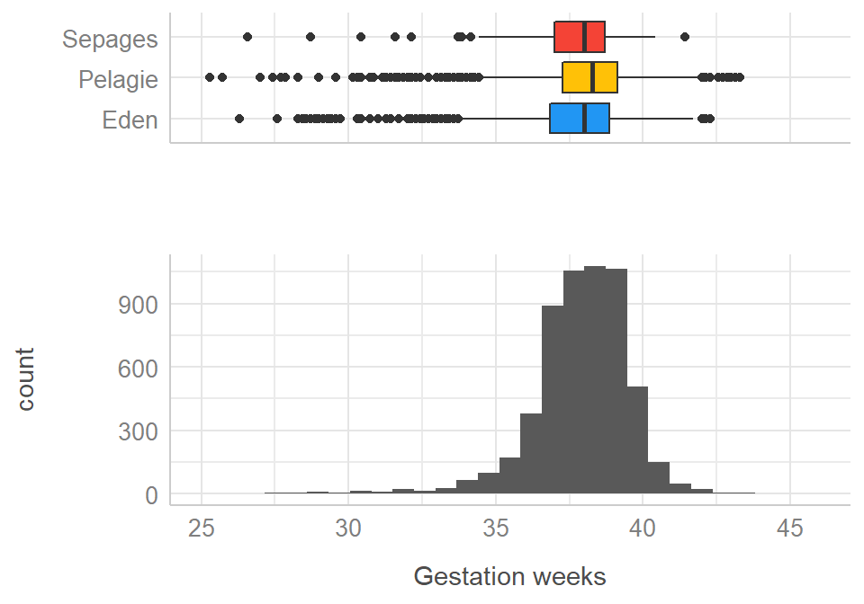

## 3.2 Above 42 GW

Number of births >= 42 GW

| clim_cohort | 42 | 43 |
| --- | --- | --- |
| Eden | 4 | 0 |
| Pelagie | 13 | 7 |

**All seems OK with LMP dates, DOB, etc**

# 4 Preterms

## 4.1 Overall

Number of preterms per center

| clim_center | preterm |
| --- | --- |
| Brittany | 123 (3.7%) |
| Grenoble | 20 (4.3%) |
| Nancy | 55 (5.7%) |
| Poitiers | 53 (5.8%) |

## 4.2 By season

Number of preterms per center

| clim_center | Winter | Spring | Summer | Autumn |
| --- | --- | --- | --- | --- |
| Brittany | 28 (3.4%) | 30 (3.8%) | 36 (4%) | 29 (3.7%) |
| Grenoble | 8 (5.6%) | 4 (4.2%) | 2 (2%) | 6 (4.5%) |
| Nancy | 9 (5%) | 11 (5.1%) | 21 (6.2%) | 14 (6.3%) |
| Poitiers | 17 (6.5%) | 9 (5.1%) | 14 (7%) | 13 (4.7%) |

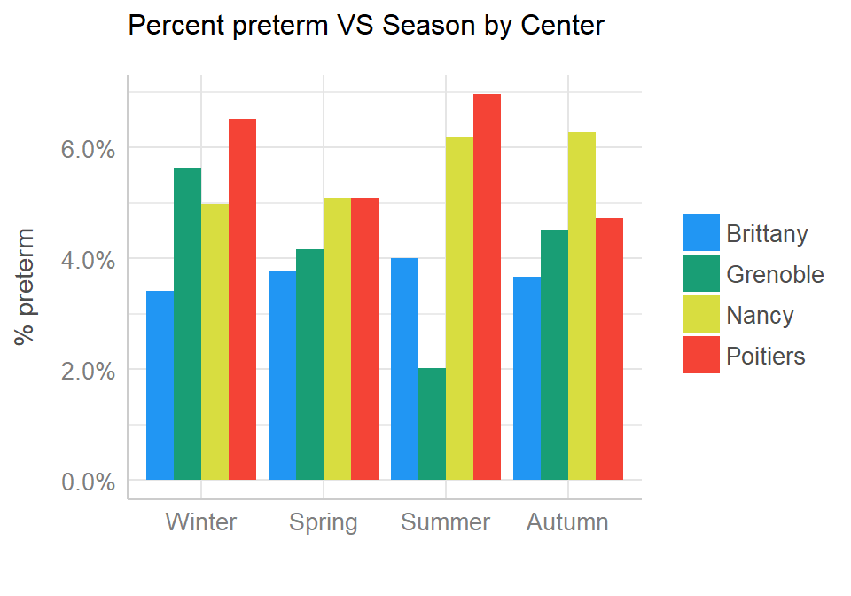

# 5 Models with no exposure

## 5.1 PTB (logistic regression)

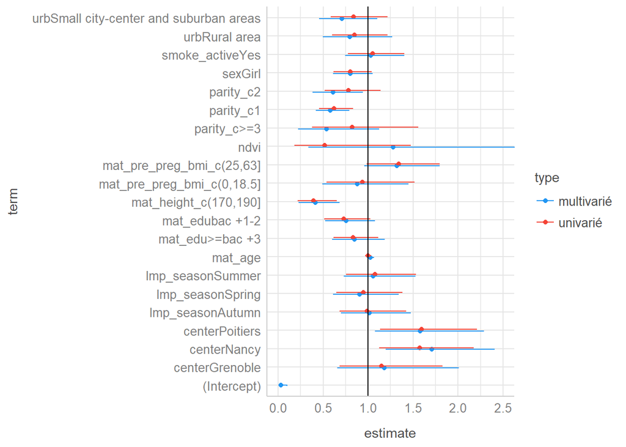

## 5.2 Gestation duration (time to event model)

With censorship at 37 GW

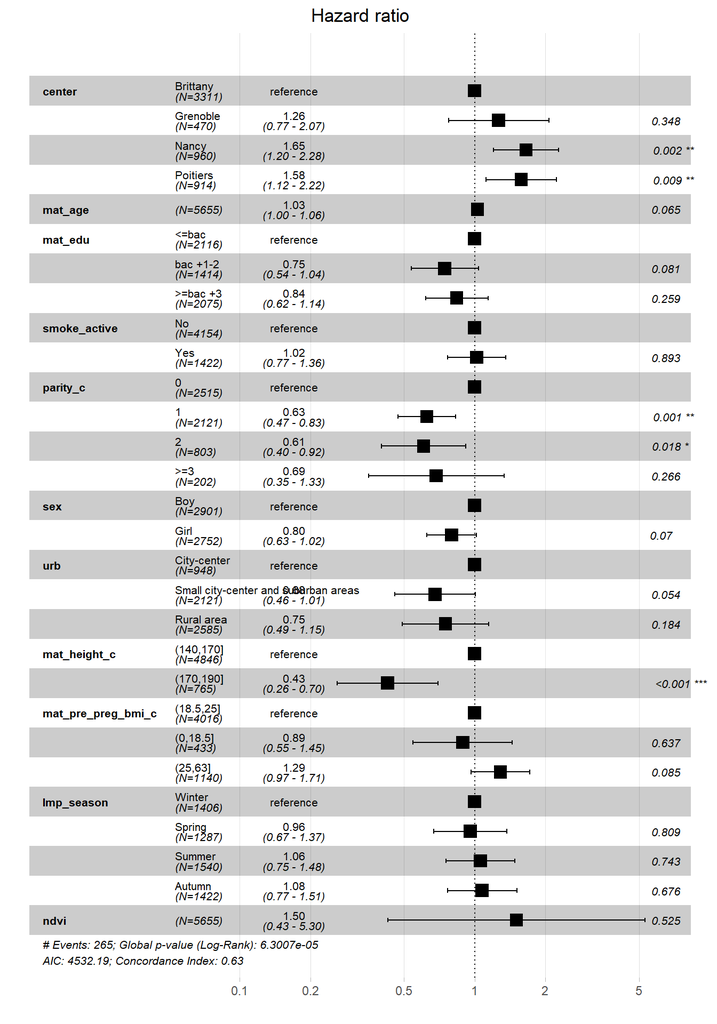

# 6 Gestation duration vs temperature descriptive

## 6.1 PTB vs temp

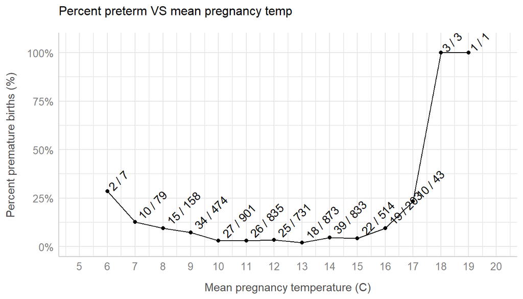

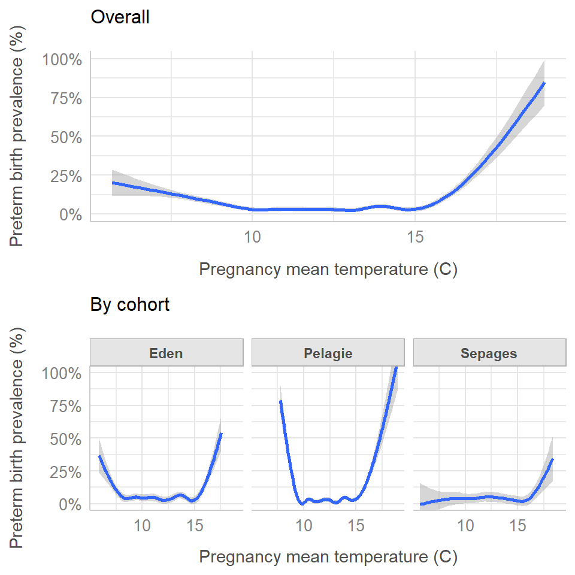

## 6.2 Gestation duration

[figure not shown]

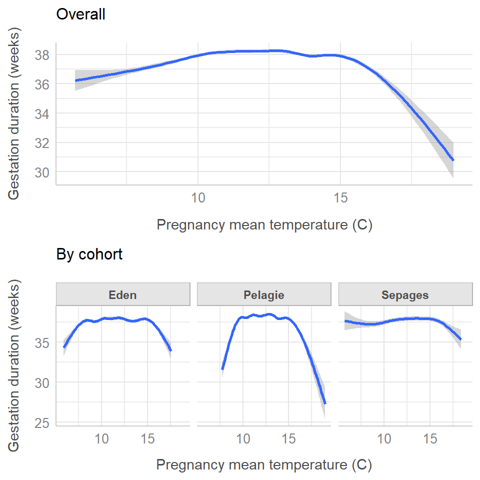

# 7 Multivariate model outputs (time to event)

Time to event with censorship at 37 gw

## 7.1 Forward

### 7.1.1 Parameter tuning (AIC)

Get AIC for model with only 1 crossbasis

| df_var | df_lag | t_mean | rh_mean |
| --- | --- | --- | --- |
| 3 | 3 | 4541 | 4543.2 |
| 3 | 4 | 4546.1 | 4548.8 |
| 3 | 5 | 4547.6 | 4552.5 |
| 3 | 6 | 4551.5 | 4556 |
| 4 | 3 | 4546.5 | 4548.8 |
| 4 | 4 | 4553.5 | 4556.3 |
| 4 | 5 | 4556.5 | 4559.2 |
| 4 | 6 | 4561.8 | 4565.9 |
| 5 | 3 | 4548.9 | 4552.3 |
| 5 | 4 | 4555.5 | 4561.8 |
| 5 | 5 | 4559.1 | 4566.3 |
| 5 | 6 | 4562.4 | 4574 |
| 6 | 3 | 4550.6 | 4550.4 |
| 6 | 4 | 4559.3 | 4560.9 |
| 6 | 5 | 4564.5 | 4566.4 |
| 6 | 6 | 4568.5 | 4572.9 |

### 7.1.2 Outputs

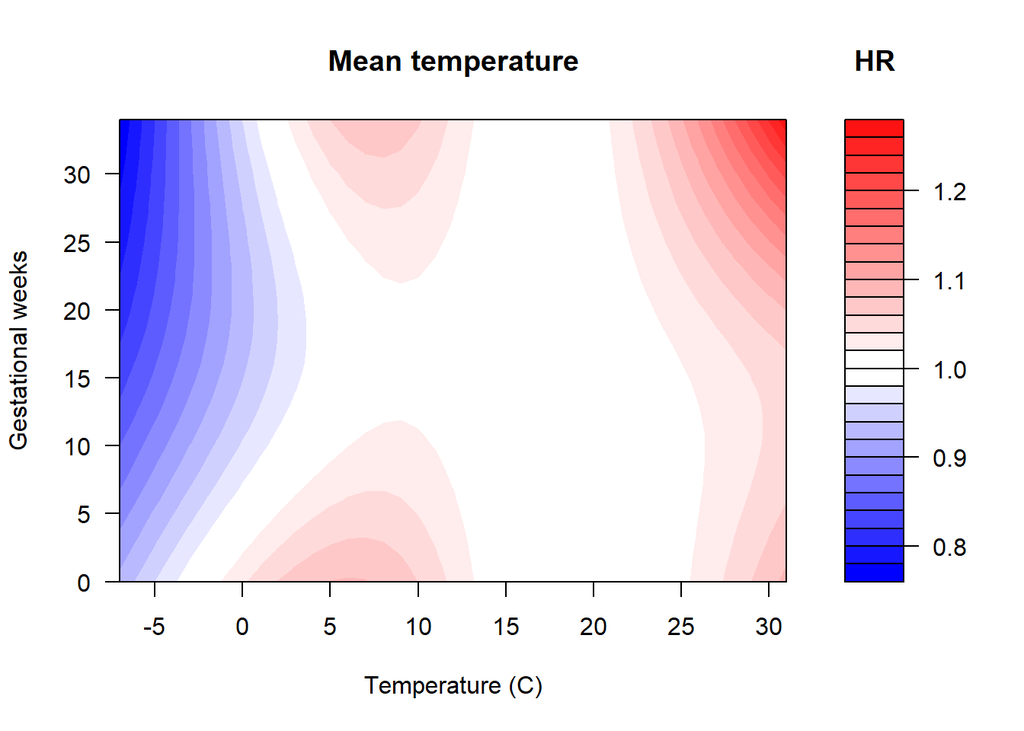

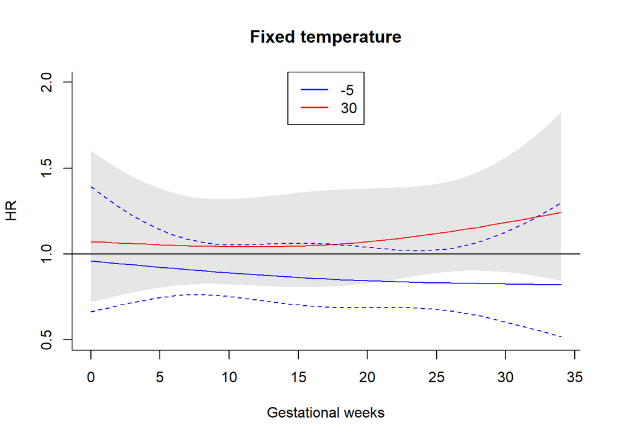

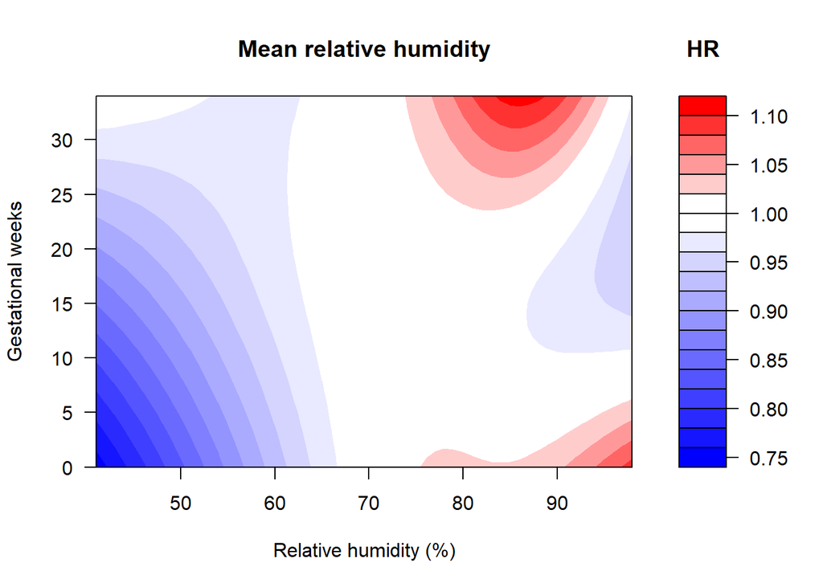

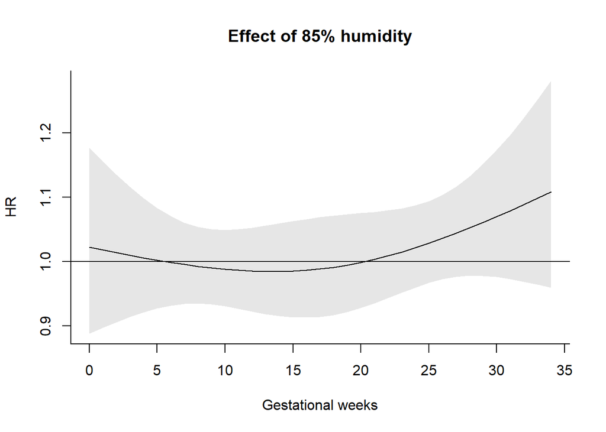

## 7.2 Backward

### 7.2.1 Parameter tuning (AIC)

| df_var | df_lag | t_mean | rh_mean |
| --- | --- | --- | --- |
| 3 | 3 | 4528.1 | 4523.3 |
| 3 | 4 | 4532.3 | 4528.7 |
| 3 | 5 | 4532.3 | 4532.2 |
| 3 | 6 | 4533.4 | 4537.3 |
| 4 | 3 | 4530.1 | 4527.9 |
| 4 | 4 | 4535.5 | 4533.2 |
| 4 | 5 | 4536.7 | 4538.5 |
| 4 | 6 | 4540.2 | 4545.2 |
| 5 | 3 | 4528.5 | 4532.2 |
| 5 | 4 | 4536.1 | 4538.6 |
| 5 | 5 | 4536.6 | 4545.1 |
| 5 | 6 | 4541.8 | 4551.6 |
| 6 | 3 | 4531.8 | 4534 |
| 6 | 4 | 4539.4 | 4542.1 |
| 6 | 5 | 4542.7 | 4550.5 |
| 6 | 6 | 4549.2 | 4556.3 |

### 7.2.2 Output

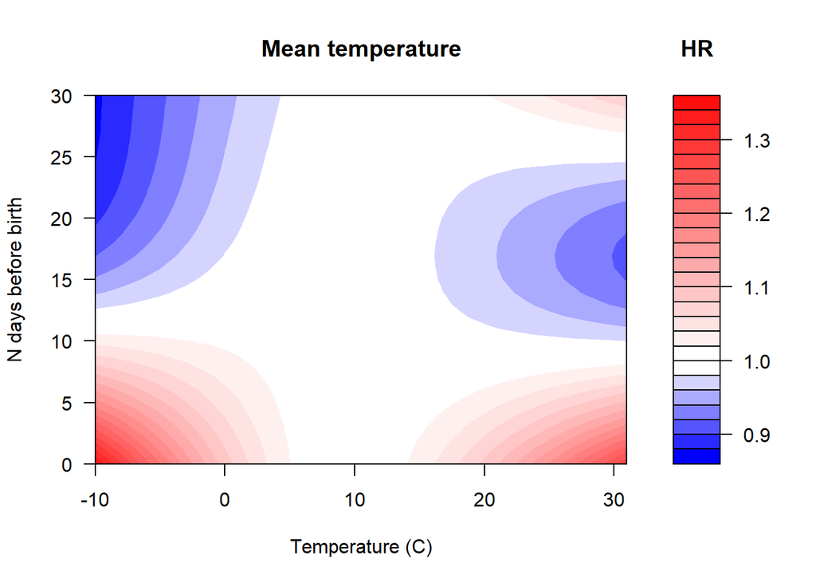

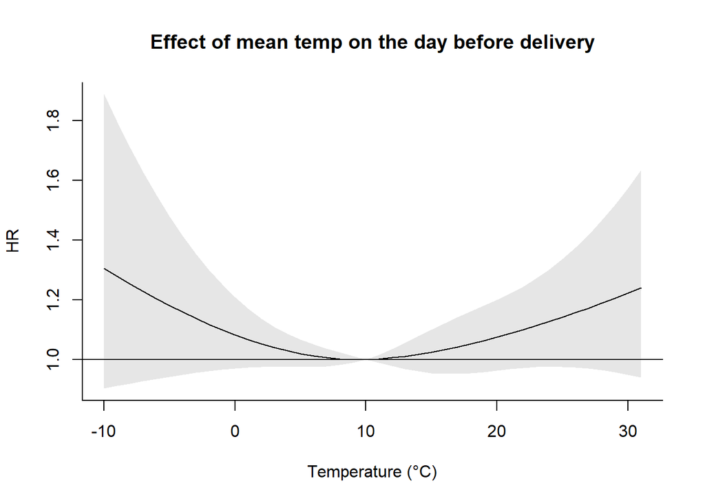

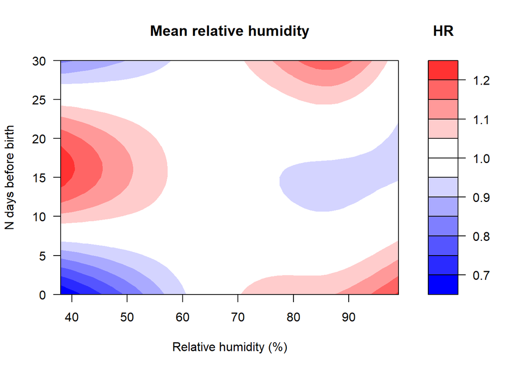